# Plotting prior distributions with ggplot2

Stefano Coretta

2019-06-17

The choice of priors is a fundamental step of the Bayesian inference process. Vasishth et al. (2018) recommend plotting the chosen priors to see if they are reasonable.

In this post I will show how to easily plot prior distributions in [ggplot2](https://ggplot2.tidyverse.org) (which is part of the [tidyverse](https://www.tidyverse.org)).

Let’s load the tidyverse first.

```r
library(tidyverse)
theme_set(theme_minimal()) # I just like this theme :)
```

## Plotting your priors

Let’s start with a simple normal prior with $\mu$ = 0 and *sd* = 1.

The plot is initialised with an empty call to `ggplot()`. As aesthetics, you only need to specify the range of *x* values in `aes()`. Here, we use `c(-4, 4)`, meaning that the *x*-axis of this plot will have these limits. For a normal distribution, it is useful to set the limits as the mean ± 4 times the standard deviation (this ensures all the distribution is shown).

The function `ggplot2::stat_function()` allows us to specify a distribution family with the `fun` argument. This arguments takes the density function (the R functions of the form *dxxx*) of the chosen distribution family, so for the normal (Gaussian) distribution we use `dnorm()`. The argument `n` specifies the number of points along which to calculate the distribution (here `101`), while `args` takes a list with the parameters of the distribution (here the mean `0` and standard deviation `1`).

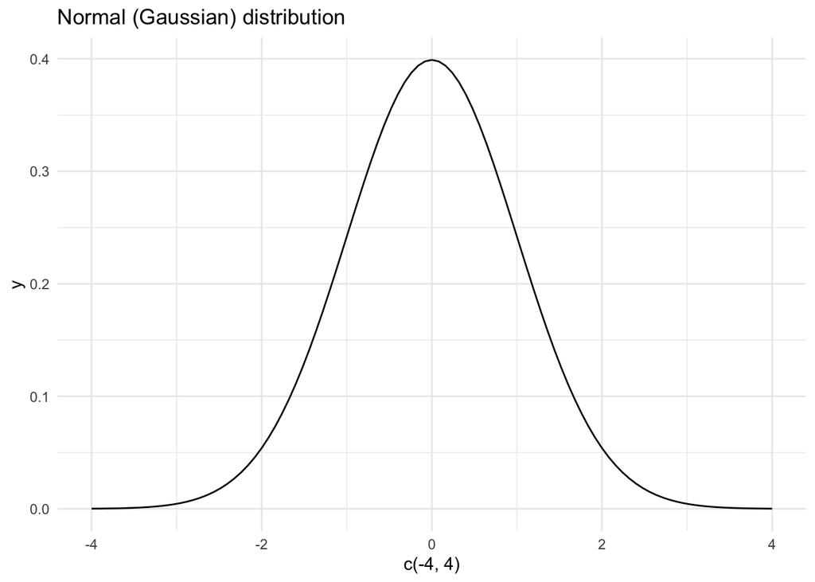

```r
ggplot() +
  aes(x = c(-4, 4)) +
  stat_function(fun = dnorm, n = 101, args = list(0, 1)) +
  labs(title = "Normal (Gaussian) distribution")
```

If you are using a half-normal prior, you can plot it by setting one of the limits to the mean.

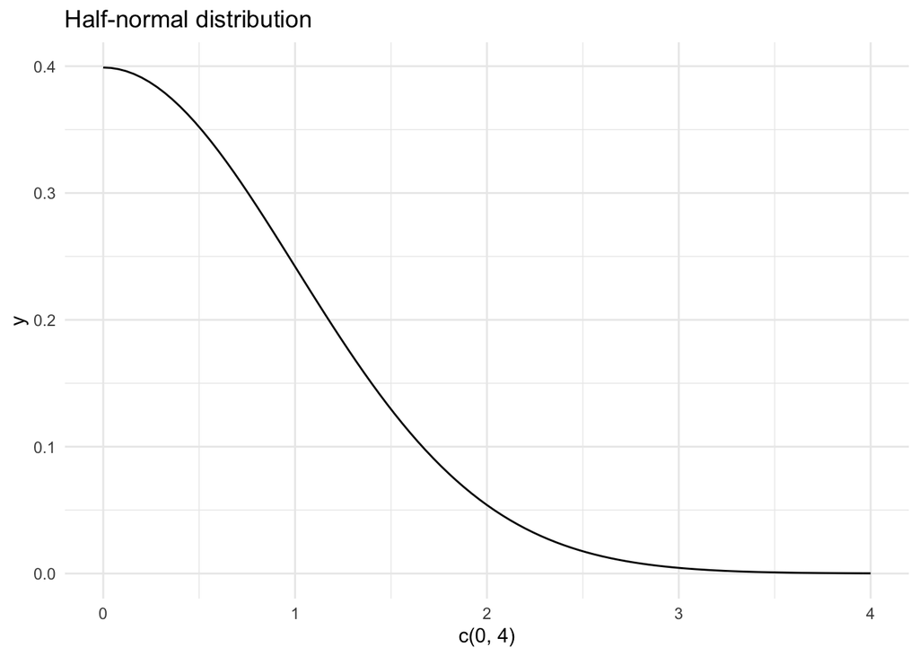

```r
ggplot() +
  # the mean is 0, only positive number are shown
  aes(x = c(0, 4)) +
  stat_function(fun = dnorm, n = 101, args = list(0, 1)) +
  labs(title = "Half-normal distribution")
```

A beta prior will be bounded between 0 and 1, so we can specify that in `aes()`. The beta distribution has two arguments, `shape1` and `shape2` (here `2` and `5`).

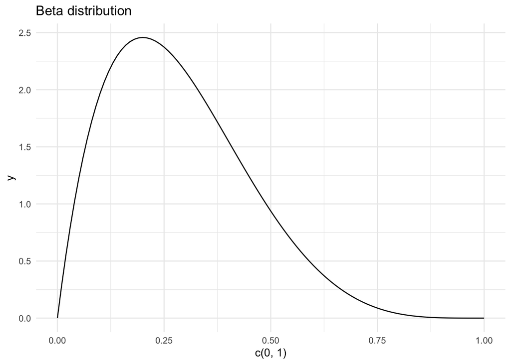

```r
ggplot() +
  aes(x = c(0, 1)) +
  stat_function(fun = dbeta, n = 101, args = list(2, 5)) +
  labs(title = "Beta distribution")
```

Another common distribution is the Cauchy.

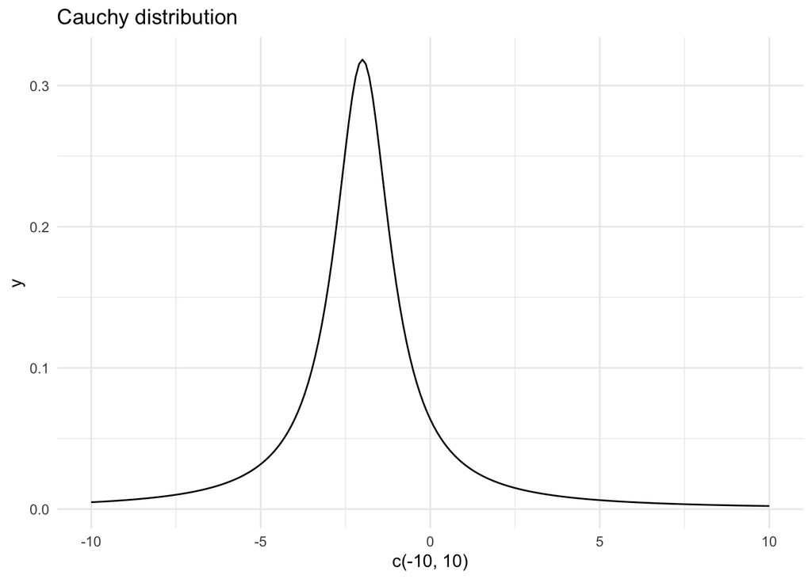

```r
ggplot() +
  aes(x = c(-10, 10)) +
  stat_function(fun = dcauchy, n = 201, args = list(-2, 1)) +
  labs(title = "Cauchy distribution")
```

The Poisson distribution can be plotted by changing the type of `geom` and using an `n` that creates only integers.

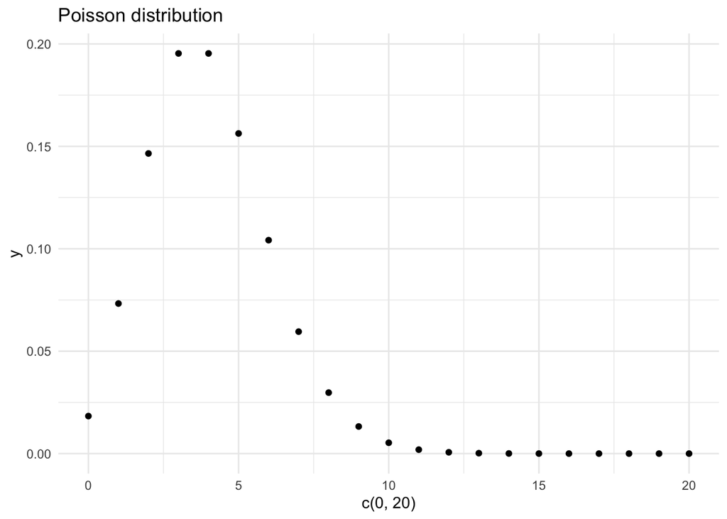

```r
# the range 0:20 includes 21 integers, so n = 21
ggplot() +
  aes(x = c(0, 20)) +
  stat_function(fun = dpois, n = 21, args = list(4), geom = "point") +
  labs(title = "Poisson distribution")
```

Of course any family with a corresponding *dxxx* function can be plotted (see `?Distributions` and package-provided families).

## References

Vasishth, Shravan, M. Beckman, B. Nicenboim, Fangfang Li, and Eun Jong Kong. 2018. “Bayesian Data Analysis in the Phonetic Sciences: A Tutorial Introduction.” *Journal of Phonetics* 71: 147–61. https://doi.org/10.1016/j.wocn.2018.07.008.